# 数学建模

### 模型知识点

### 优化模型-优化算法-模拟退火算法

**Wang Haihua**

🚅 🚋😜 🚑 🚔

## 模拟退火算法

模拟退火算法 (Simulated Annealing，SA) 最早的思想是由 N. Metropolis 等人于1953年提出。1983年, S. Kirkpatrick 等成功地将退火思想引入到组合优化领域。它是**基于 Monte-Carlo 迭代求解策略的一种随机寻优算法**，其出发点是基于物理中固体物质的退火过程与一般组合优化问题之间的相似性。模拟退火算法从某一较高初温出发，伴随温度参数的不断下降,结合概率突跳特性在解空间中随机寻找目标函数的全局最优解，即在局部最优解能概率性地跳出并最终趋于全局最优。

与具有陷入局部最小值的缺点的基于梯度的方法(也就是刚才提到的爬山法)以及其他确定性搜索方法不同，SA 的主要优势在于其具有避免陷入局部最小值的能力。事实上，已经证明，如果足够的随机性与非常缓慢的冷却结合使用，模拟退火将收敛到其全局最优性。实质上，SA 是一种搜索算法，**可以视为马尔可夫链**，能够在合适的条件下收敛。

模拟退火在建模比赛中最主要的应用是模型求解，特别是最优化问题（组合优化问题），如旅行商问题 ( TSP）、最大截问题(Max Cut Problem)、0-1背包问题(Zero OneKnapsack Problem)、图着色问题(Graph Colouring Problem)、调度问题(Scheduling Problem)等等。

求以下函数的最小值： $$ f(x)=x^3-60x^2-4x+6,x\in [0,100] $$

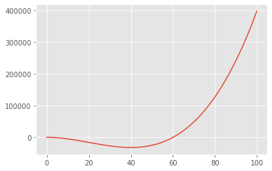

```python
import numpy as np
import matplotlib.pyplot as plt
plt.style.use('ggplot')
%matplotlib inline
x = [0.1*i for i in range(0,1000)]
y = [i**3 - 60 *i **2 - 4 * i + 6 for i in x]
plt.plot(x,y)
```

### 物理学中的退火

**加温过程**：增强粒子运动，消除系统原先可能存在的非均匀态。

**等温过程**：对于与环境换热而温度不变的封闭系统，系统状态的自发变化总是朝自由能减少的方向进行，当自由能达到最小时，系统达到平衡。

**冷却过程**：使粒子热运动减弱并渐趋有序，系统能量逐渐下降，从而得到低能的晶体结构。

### Boltzman 概率分布

在统计学中，玻尔兹曼分布的表达形式为 $$ F(state) \propto e^{-E/kT} $$ 上式中，$E$是能量状态，$kT$是玻尔兹曼常数和热力学温度的乘积。

- 同一个温度，分子停留在能量小状态的概率大于停留在能量大状态的概率
- 温度越高，不同能量状态对应的概率相差越小，温度足够高时，各状态对应概率基本相同。
- 随着温度的下降，能量最低状态对应概率越来越大，温度趋于0时，其状态趋于1

### 劣解接受概率（Metropolis准则）

又称做状态接受函数，这里是模拟退火法这个名字的来源，模仿固体退火原理，随着温度的下降（迭代次数上升），能量逐渐稳定。即劣解的接受概率p逐渐下降，其公式为： $$ \displaystyle p=\left\{\begin{array}{ll}{1,} & {E\left(x_{new}\right) < E\left(x_{o l d}\right)} \\ {exp \left({-\dfrac{E\left(x_{n e w}\right)-E\left(x_{o l d}\right)}{T}}\right),} & {E\left(x_{n e w}\right) \geq E\left(x_{o l d}\right)}\end{array}\right. $$

从公式中可以看出这是求最小值时的分布，因为当新的解小于旧解时百分百接受。又可以看出当$E\left(x_{n e w}\right) \geq E\left(x_{o l d}\right)$时，$p$恒在[0, 1]之间。可以看到，随着时间推移，温度越低，对于劣解的接受概率越低。

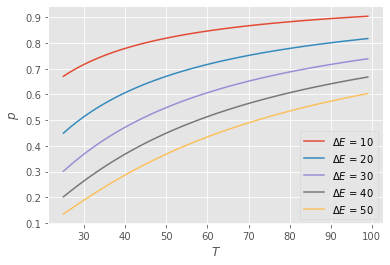

```python
deltaEList = [10,20,30,40,50]
for deltaE in deltaEList:
    p_list = []
    t_list = [i for i in range(25,100)]
    for T in range(25,100):
        p_list.append(np.exp(- deltaE/T))
    plt.plot(t_list,p_list,label = r'$\Delta E$ = ' + str(deltaE))
plt.legend()
plt.xlabel(r'$T$')
plt.ylabel(r'$p$')
```

### 初始化

关于初始温度，初温越大，获得高质量解的机率越大，但花费较多的计算时间，原理可以从上面的图中或者结合下面温度随时间变化进行理解、解释，温度越高对于劣解的接受能力越大（搜索范围越大），下降速度越慢（求解速度下降）。

关于初始解如何设定一般有以下方法：

（3）利用经验公式。

### 温度更新

**更新函数1:对数函数** $$ T(t+1)=\frac{T_{0}}{\ln (1+t)} $$

如果使用这种温度更新，不管初始温度如何，都有一个先加热后散热的过程。即先提高搜索范围，再慢慢的减少搜索范围。

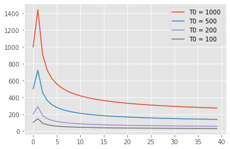

```python
T0_list = [1000,500,200,100]
for T0 in T0_list:
    T_list = []
    t_list = [i for i in range(1,40)]
    T_list.append(T0)
    for t in t_list:
        T_list.append(T0/np.log(t+1))
    plt.plot([i for i in range(40)],T_list,label = 'T0 = '+ str(T0))
plt.legend()
```

指数衰减，通常$0.8 < \alpha <0.99$。

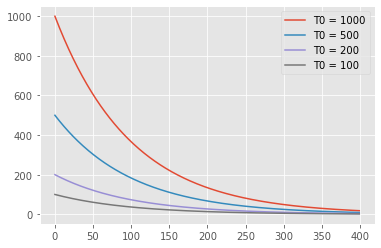

```python
T0_list = [1000,500,200,100]
alpha = 0.99
for T0 in T0_list:
    T_list = []
    t_list = [i for i in range(1,400)]
    T_list.append(T0)
    for t in t_list:
        T_list.append(alpha * T_list[-1] )
    plt.plot([i for i in range(400)],T_list,label = 'T0 = '+ str(T0))
plt.legend()
```

**更新函数3**： $$ T(t)= \frac{T_{0}}{1+t} $$

t是迭代次数。按照反比例函数衰减，类似更新函数2。

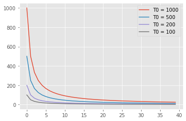

```python
T0_list = [1000,500,200,100]
alpha = 0.99
for T0 in T0_list:
    T_list = []
    t_list = [i for i in range(1,40)]
    T_list.append(T0)
    for t in t_list:
        T_list.append(T0/(t+1))
    plt.plot([i for i in range(40)],T_list,label = 'T0 = '+ str(T0))
plt.legend()
```

### 算法步骤

[figure not shown]

**步骤**

1. 初始化温度$T$，初始解状态$S$，每个温度$t$下的迭代次数$L$；
2. 当$k = 1,2,\cdots,L$时，进行3~6；
3. 对当前解进行变换得到新解$S'$（例如对某些解中的元素进行互换，置换）；
4. 计算增量$\Delta t'=C(S')-C(S)$，其中$C(S)$为评价函数；
5. 若$\Delta t'<0$则接受$S'$作为新的当前解，否则以概率$e^{-\Delta t'/(KT)}$接受$S′$作为新的当前解($K$为玻尔兹曼常数，数值为：$K=1.380650× 10^{-23} J/K$）；（实际上，为了简便运算，而又不失一般性，通常忽略$K$，令$K=1$）
6. 如果满足终止条件则输出当前解作为最优解，结束程序；
7. 减小$T$，转到第2步，直到$T$小于初始设定的阈值。

##### step0初始化

##### step1产生新解

为便于后续的计算和接受，减少算法耗时，通常选择由当前新解经过简单地变换即可产生新解的方法，如对构成新解的全部或部分元素进行置换、互换等，注意到产生新解的变换方法决定了当前新解的邻域结构，因而对冷却进度表的选取有一定的影响。

##### step2计算目标函数差

因为目标函数差仅由变换部分产生，所以目标函数差的计算最好按增量计算。事实表明，对大多数应用而言，这是计算目标函数差的最快方法。

##### step3判断新解是否被接受

判断的依据是一个接受准则，最常用的接受准则是 Metropolis 准则

##### step4当新解被确定接受时，用新解代替当前解

当新解被确定接受时，用新解代替当前解，这只需将当前解中对应于产生新解时的变换部分予以实现，同时修正目标函数值即可。此时，当前解实现了一次迭代。可在此基础上开始下一轮试验。而当新解被判定为舍弃时，则在原当前解的基础上继续下一轮试验。

##### step5温度更新，下一轮循环

### 小结

模拟退火其实也是一种Greedy算法，但是它的搜索过程引入了随机因素。**模拟退火算法以一定的概率来接受一个比当前解要差的解，因此有可能会跳出这个局部的最优解，达到全局的最优解。**以上图为例，模拟退火算法在搜索到局部最优解B后，会以一定的概率接受向右继续移动。也许经过几次这样的不是局部最优的移动后会到达B 和C之间的峰点，于是就跳出了局部最小值B。

[figure not shown]

模拟退火算法来源于固体退火原理，将固体加温至充分高，再让其徐徐冷却，加温时，固体内部粒子随温升变为无序状，内能增大，而徐徐冷却时粒子渐趋有序，在每个温度都达到平衡态，最后在常温时达到基态，内能减为最小。

根据 Metropolis 准则，粒子在温度$T$时趋于平衡的概率为$e^{-\frac{\Delta E}{kT}}$，其中$E$为温度$T$时的内能，$\Delta E$为其改变量，$k$为 Boltzmann 常数。

用固体退火模拟组合优化问题，将内能$E$模拟为目标函数值$f$，温度$T$演化成控制参数$t$，即得到解组合优化问题的模拟退火算法：

由初始解i和控制参数初值t开始，对当前解重复“产生新解→计算目标函数差→接受或舍弃”的迭代，并逐步衰减$t$值，算法终止时的当前解即为所得近似最优解，这是基于蒙特卡罗迭代求解法的一种启发式随机搜索过程。退火过程由冷却进度表(Cooling Schedule)控制，包括控制参数的初值$t$及其衰减因子$\Delta t$、每个$t$值时的迭代次数$L$和停止条件$S$。

特别关注： 初始化方法、 温度更新方法、 产生新解方法

## 模拟退火算法案例：函数寻优（最小值）

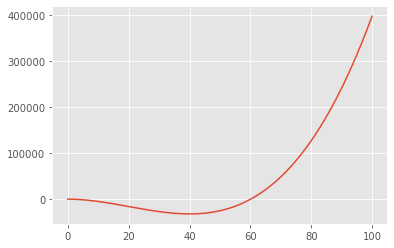

```python
%matplotlib inline
import numpy as np
import matplotlib.pyplot as plt
import math

#define aim function
def aimFunction(x):
    y=x**3-60*x**2-4*x+6
    return y
x=[i/10 for i in range(1000)]
y=[0 for i in range(1000)]
for i in range(1000):
    y[i]=aimFunction(x[i])

plt.plot(x,y)
```

```python
T=1000 #initiate temperature
Tmin=10 #minimum value of terperature
x=np.random.uniform(low=0,high=100)#initiate x
k=50 #times of internal circulation
y=0#initiate result
t=0#time
while T>=Tmin:
    for i in range(k):
        #calculate y
        y=aimFunction(x)
        #generate a new x in the neighboorhood of x by transform function
        xNew=x+np.random.uniform(low=-0.055,high=0.055)*T
        if (0<=xNew and xNew<=100):
            yNew=aimFunction(xNew)
            if yNew-y<0:
                x=xNew
            else:
                #metropolis principle
                p=math.exp(-(yNew-y)/T)
                r=np.random.uniform(low=0,high=1)
                if r<p:
                    x=xNew
    t+=1
#     print (t)
    T=1000/(1+t)

print ('x:',x,'|y:',aimFunction(x))
```

```
x: 39.93773808249782 |y: -32153.51860090895
```

```python
num = 100
solutionnew = np.arange(num)
solutionnew
```

```
array([ 0,  1,  2,  3,  4,  5,  6,  7,  8,  9, 10, 11, 12, 13, 14, 15, 16,
       17, 18, 19, 20, 21, 22, 23, 24, 25, 26, 27, 28, 29, 30, 31, 32, 33,
       34, 35, 36, 37, 38, 39, 40, 41, 42, 43, 44, 45, 46, 47, 48, 49, 50,
       51, 52, 53, 54, 55, 56, 57, 58, 59, 60, 61, 62, 63, 64, 65, 66, 67,
       68, 69, 70, 71, 72, 73, 74, 75, 76, 77, 78, 79, 80, 81, 82, 83, 84,
       85, 86, 87, 88, 89, 90, 91, 92, 93, 94, 95, 96, 97, 98, 99])
```

# Questions???

**参考文献**

- ThomsonRen 的 github https://github.com/ThomsonRen/mathmodels
- youcans Python小白的数学建模课 https://www.zhihu.com/column/c_1381900867424075776
- 司守奎 的 《Python数学实验与建模》